# Статистический анализ Индивидуальное домашнее задание №3 Вариант 6

Звегинцева Елизавета

23.12.2020

#### Результаты статистического эксперимента приведены в таблице 1. Требуется оценить характер (случайной) зависимости переменной Y от переменной X.

##### Таблица 1. $\alpha_1 = 0.05; h = 2.30$

```
##   [,1] [,2] [,3] [,4] [,5] [,6] [,7] [,8]  [,9] [,10] [,11] [,12] [,13] [,14]
## x 5.00    1 3.00 3.00 3.00 6.00 3.00 3.00  2.00  3.00  2.00  5.00  3.00  1.00
## y 7.35   12 0.55 8.63 7.83 7.17 6.25 9.55 14.33  8.98  9.15 13.19  6.92 10.85
##   [,15] [,16] [,17] [,18] [,19] [,20] [,21] [,22] [,23] [,24] [,25] [,26] [,27]
## x   2.0  3.00  5.00  1.00  2.00  3.00  4.00  4.00  4.00   3.0  3.00  3.00  3.00
## y   1.5  3.85 11.55 11.31  5.97  8.75  8.12 11.46  7.14  11.1 13.87 11.47  9.07
##   [,28] [,29] [,30] [,31] [,32] [,33] [,34] [,35] [,36] [,37] [,38] [,39] [,40]
## x  2.00  0.00  4.00  3.00  2.00  3.00  5.00  5.00   2.0  5.00  4.00  3.00  2.00
## y  5.28 11.22 13.78 11.74  9.45 18.86 18.22  9.94   1.8  3.94 13.68 17.72  9.44
##   [,41] [,42] [,43] [,44] [,45] [,46] [,47] [,48] [,49] [,50]
## x  4.00   2.0  3.00  2.00  4.00  4.00  3.00  2.00  2.00  3.00
## y 10.66  16.6  3.19  8.26  8.94  6.32  6.71  6.35  4.87  7.75
```

#### *Задание 1*

##### Построить графически результаты эксперимента. Сформулировать линейную регрессионную модель переменной Y по переменной X. Построить МНК оценки параметров сдвига $\beta_0$ и масштаба $\beta_1$. Построить полученную линию регрессии. Оценить визуально соответствие полученных данных и построенной оценки.

$$\begin{align}
& Y_i = \beta_0+\beta_1X_i + \varepsilon_i, \varepsilon_i - N(0, \sigma^2) \\
& \beta_1 = \frac{\bar{xy}-\bar{x}\bar{y}}{\bar{x^2}-\bar{x}^2} = 0.2232792 \\
& \beta_0 = \bar{Y} - \beta_1\bar{X} = 8.5738312 \\
& Y = \hat{\beta_1}X + \beta_0 = 0.2232792X + 8.5738312
\end{align}$$

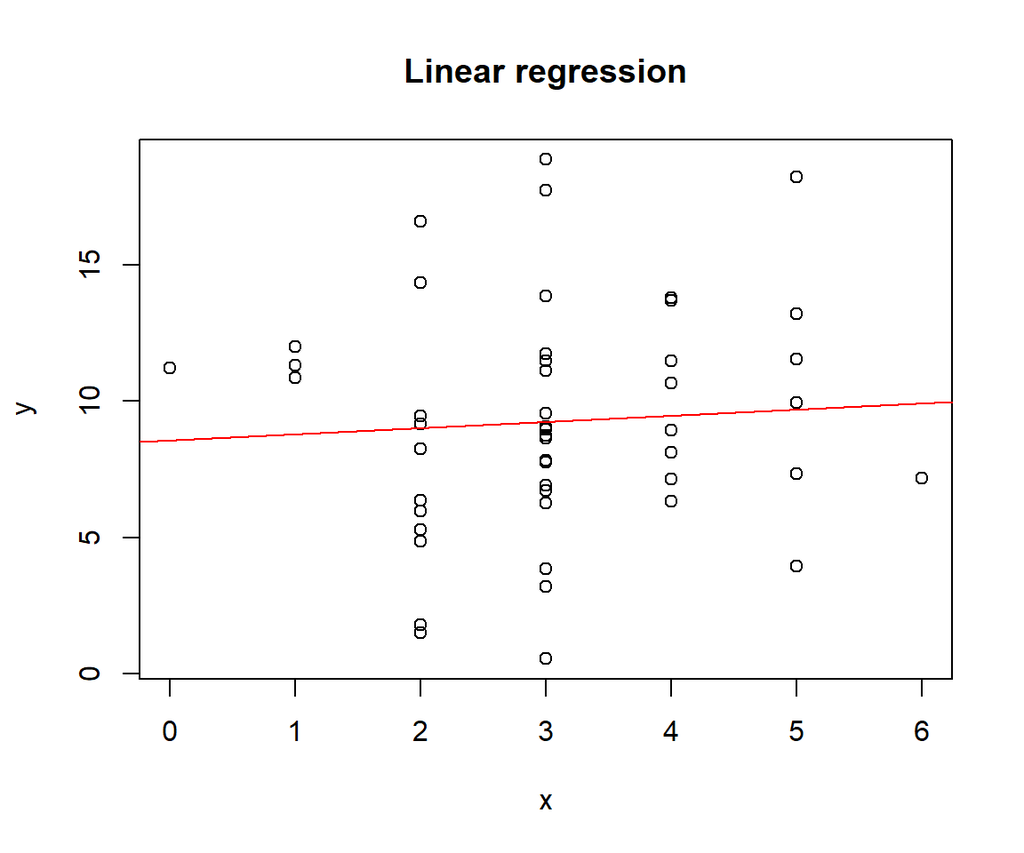

#### *Задание 2*

##### Построить и интерпретировать несмещенную оценку дисперсии. На базе ошибок построить гистограмму с шагом $h$. Проверить гипотезу нормальности ошибок на уровне $\alpha_1$ по $\chi^2$. Оценить расстояние полученной оценки до класса нормальных распределений по Колмогорову. Визуально оценить данный факт.

$$\begin{align}
\hat{\sigma}^2=\frac{1}{n-2}&\sum\limits_{1}^{n}(Y-\bar{Y})^2 = 17.409795 \\
\varepsilon_i=&Y_i -\hat{\beta_1}X_i - \hat{\beta_0}
\end{align}$$

###### $\varepsilon_1, ..., \varepsilon_n:$

```
##  [1] -2.3402273  3.2028896 -8.6936688 -0.6136688 -1.4136688 -2.7435065
##  [7] -2.9936688  0.3063312  5.3096104 -0.2636688  0.1296104  3.4997727
## [13] -2.3236688  2.0528896 -7.5203896 -5.3936688  1.8597727  2.5128896
## [19] -3.0503896 -0.4936688 -1.3469481  1.9930519 -2.3269481  1.8563312
## [25]  4.6263312  2.2263312 -0.1736688 -3.7403896  2.6461688  4.3130519
## [31]  2.4963312  0.4296104  9.6163312  8.5297727  0.2497727 -7.2203896
## [37] -5.7502273  4.2130519  8.4763312  0.4196104  1.1930519  7.5796104
## [43] -6.0536688 -0.7603896 -0.5269481 -3.1469481 -2.5336688 -2.6703896
## [49] -4.1503896 -1.4936688
```

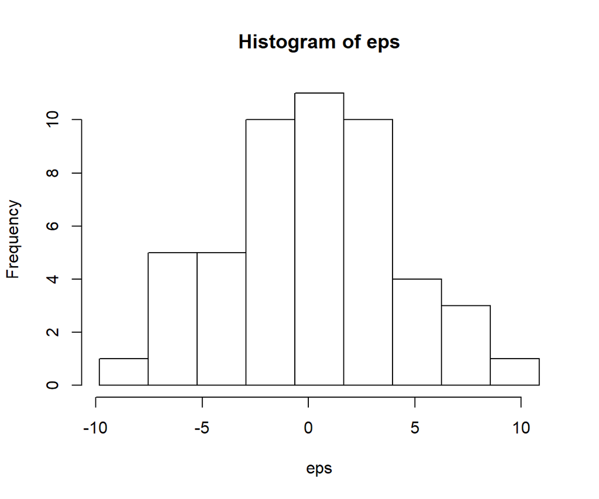

$$\begin{align}
& H_0:\varepsilon_1, ..., \varepsilon_n \sim N(0, \sigma^2) \\
& \sum\limits_{i=1}^{r}\frac{n_i-np_i(0, \sigma^2))^2}{np_i(0, \sigma^2)} \rightarrow \chi^2_{кр}
\end{align}$$

Метод минимизации хи-квадрат

$$\begin{equation}
\underset{\sigma^2}{argmin}\sum\limits_{i=1}^{r}\frac{n_i-np_i(0, \sigma^2))^2}{np_i(0, \sigma^2)}
\end{equation}$$

##### Разделим выборку на 6 зон:

| Интервал | $(-\infty; -4.6)$ | $(-4.6; -2.3)$ | $(-2.3; 0)$ | $(0; 2.3)$ | $(2.3; 4.6)$ | $(4.6; \infty)$ |
| --- | --- | --- | --- | --- | --- | --- |
| $m_i$ | 6 | 11 | 9 | 11 | 7 | 6 |

##### Задача реализована в R с помощью скрипта:

```r
csq <- function(sgm.sq){
  prob <- pnorm(up, 0, sgm.sq) - pnorm(lw, 0, sgm.sq)
  return (sum((m-n*prob)^2)/prob/n)
}
XM <- nlm(csq, sqrt(s))
XM$estimate^2; XM$minimum
```

##### Получаем $\hat{\sigma}^2=15.8410762$ и $\chi^2_{набл}=1.6761584$

$$\begin{align}
l&=r - d - 1 = 4 \\
\chi^2_{кр} &=9.487729 \\
\chi^2_{набл}=1.6761584 < \chi^2_{кр} & = 9.487729 \Rightarrow \text{гипотеза $H_0$ принимается}
\end{align}$$

##### Оценим расстояние оценки до класса нормальных распределений по Колмогорову. Минимизируем статистику Колмогорова с помощью следующего скрипта:

```r
kolm.stat<-function(s){
  sres<-sort(eps)
  fdistr<-pnorm(sres,0,s)
  max(abs(c(0:(n-1))/n-fdistr),abs(c(1:n)/n-fdistr))
}
ks.dist<-nlm(kolm.stat, XM$estimate)
```

##### Получаем расстояние $D = 0.0740055$ и $\tilde{\sigma}^2 = 13.8237648$. Ниже представлены эмпирическая функция распределения ошибок и фукнция распределения $N(0, \tilde{\sigma}^2)$.

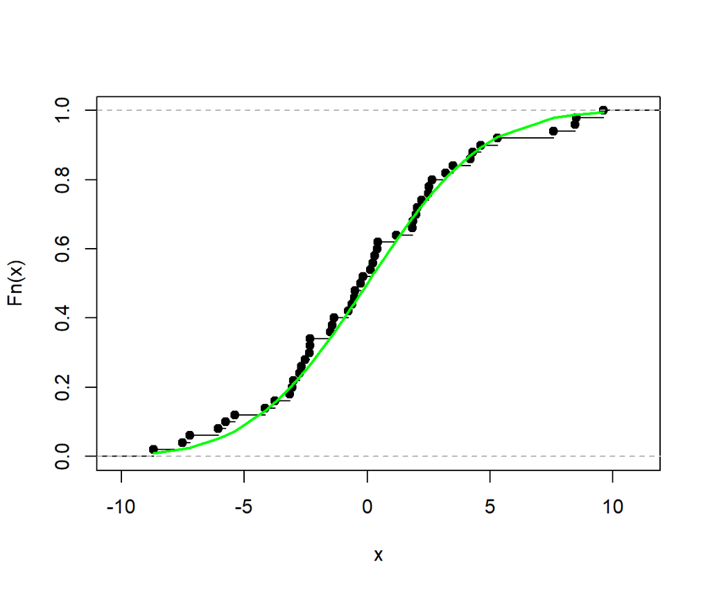

#### *Задание 3*

##### В предположении нормальности ошибок построить доверительные интервалы для параметров $\beta_0$ и $\beta_1$ уровня доверия $1-\alpha_1$. Построить доверительный эллипс уровня доверия $1-\alpha_1$ для $(\beta_0, \beta_1)$ (вычислить его полуоси).

$$\begin{align}
\psi&=C^T\beta \\
\hat{\psi}\sim N(\psi, \sigma^2b), \sigma^2b&=var(\hat{\psi})=\sigma^2C^T(XX^T)^{-1}C \\
\frac{\hat{\psi}-\psi}{\sigma\sqrt{b}}\sim N(0, 1);&\frac{(n-r)s^2}{\sigma^2}\sim \chi^2_{n-r}\Rightarrow \frac{\hat{\psi}-\psi}{s\sqrt{b}}\sim S_{n-r} \\
x_{\alpha}:&S_{n-r}(x_{\alpha})=1-\frac{\alpha}{2} \\
P(-x_{\alpha} \leqslant \frac{\hat{\psi}-\psi}{s\sqrt{b}} \leqslant &x_{\alpha})=P(\hat{\psi}-x_{\alpha}s\sqrt{b} \leqslant \psi \leqslant \hat{\psi}+x_{\alpha}s\sqrt{b}) \\
x_{\alpha}&=2.0106348 \\
\beta_0 \in (5.3790109; &11.7686514) \text{ - ДИ с уровнем доверия }1-\alpha \\
\beta_1 \in (-0.7524943; &1.1990528) \text{ - ДИ с уровнем доверия }1-\alpha
\end{align}$$

$$\begin{align}
&\frac{(\hat{\psi}-\psi)^T(C^T(XX^T)^{-1}C)^{-1}(\hat{\psi}-\psi)}{\sigma^2}\sim\chi^2_q \\
&\frac{((\hat{\psi}-\psi)^T(C^T(XX^T)^{-1}C)^{-1}(\hat{\psi}-\psi)q\sigma^2)}{\frac{n-r}{n+r}\cdot\frac{s^2}{\sigma^2}}=\frac{(\hat{\psi}-\psi)^T(C^T(XX^T)^{-1}C)^{-1}(\hat{\psi}-\psi)}{qs^2}\sim F_{q, n-r}
\end{align}$$
$$\begin{align}
& x_{\alpha}: F_{q, n-r}(x_{\alpha})=1-\alpha \\
& \left\{ \psi: (\hat{\psi}-\psi)^T(C^T(XX^T)^{-1}C)^{-1}(\hat{\psi}-\psi) \leqslant s^2qx_{\alpha} \right\} \\
& x_{\alpha} = 3.1907273 \\
& \begin{pmatrix} \beta_1-\hat{\beta_1} & \beta_0-\hat{\beta_0} \end{pmatrix} \begin{pmatrix} 0.0135281 & -0.0411255 \\ -0.0411255 & 0.1450216 \end{pmatrix} \begin{pmatrix} \beta_1-\hat{\beta_1} \\ \beta_0-\hat{\beta_0} \end{pmatrix} \leqslant 111.0998179
\end{align}$$

Собственные числа матрицы: **0.1568245, 0.0017253**  
После ортогонального преобразования получаем:

$$\begin{align}
0.1568245(\beta_1^*-0.2232792)^2&+0.0017253(\beta_0^*+8.5738312)^2 \leqslant 111.0998179 \\
\frac{(\beta_1^*-0.2232792)^2}{26.6164225^2}&+\frac{(\beta_0^*+8.5738312)^2}{253.7637865^2} \leqslant 1
\end{align}$$

#### *Задание 4*

##### Сформулировать гипотезу независимости переменной Y от переменной X. Провести проверку значимости.

$$\begin{align}
& \psi=C^T\beta; \hat{\psi}\sim N(\psi, \sigma^2C^T(XX^T)^{-1}C) \\
& H_0: \psi=0 \\
& \text{Статистика F-критерия:} \\
& F=\frac{\hat{\psi^T(C^T(XX^T)^{-1}C)^{-1}\hat{\psi}}}{qs^2}\overset{H_0}{\sim}F_{q, n-r} \\
& F=0.2116727 \\
& x_{\alpha}: F_{q, n-r}(x_{\alpha})=1-\alpha; \phi(Y, X)=1_{F>x_{\alpha}} \\
& x_{\alpha}=4.0426521 \\
& H_1: \hat{\psi}=\beta_1
\end{align}$$
$$\begin{align}
& F<x_{\alpha}\Rightarrow \text{ Принимаем гипотезу $H_0$, переменная 𝑌 независима с переменной 𝑋 на уровне значимости 𝛼}\\
& 0.6475369 \text{ – наибольшее значение уровня значимости, на котором нет оснований отвергнуть данную гипотезу.}
\end{align}$$

#### *Задание 5*

##### Сформулировать модель, включающую дополнительный член с $X^2$. Построить МНК оценки параметров $\beta_1, \beta_2, \beta_3$ в данной модели. Изобразить графически полученную регрессионную зависимость.

$$\begin{align}
& Y_i = \beta_3+\beta_2X_i+\beta_1X_i^2+\varepsilon_i, \varepsilon_i\sim N(0, \sigma^2) \\
& \hat{\beta}=(X^TX)^{-1}X^TY \\
& \hat{\beta}=\begin{pmatrix}\hat{\beta_1} \\ \hat{\beta_2} \\ \hat{\beta_3}\end{pmatrix}=\begin{pmatrix}0.2047166 \\ -1.0522118 \\ 10.2567615\end{pmatrix}
\end{align}$$

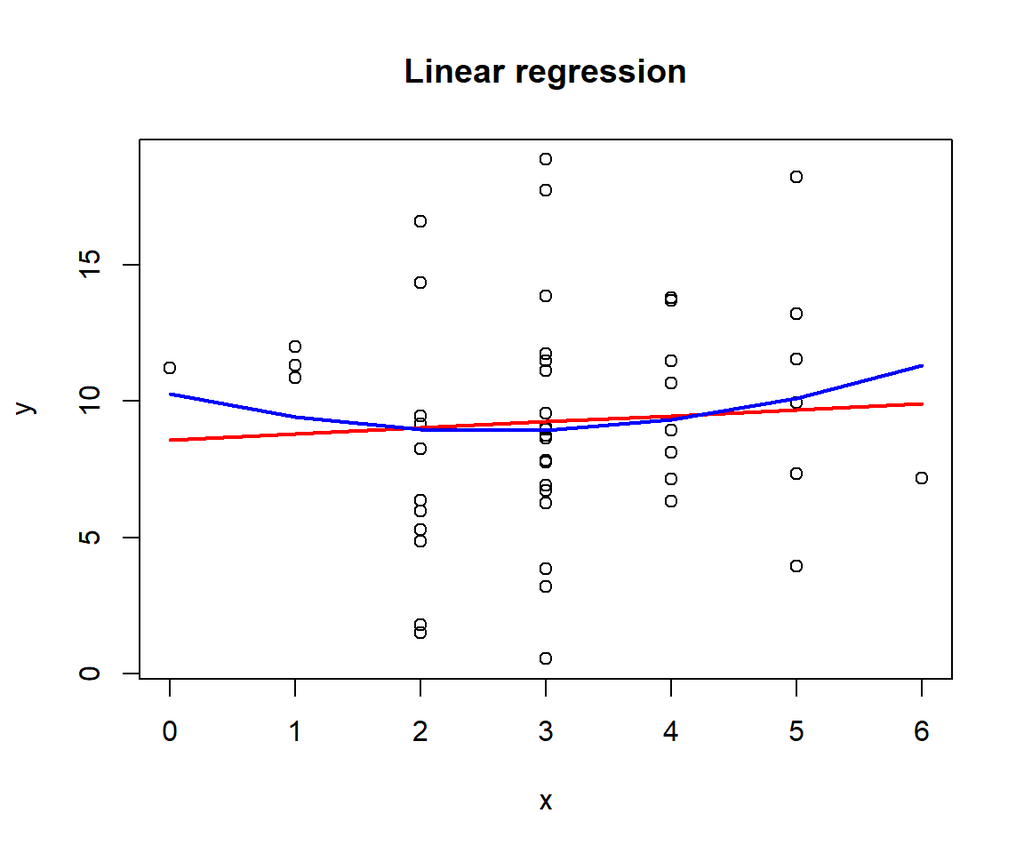

#### *Задание 6*

##### Построить несмещенную оценку дисперсии. Провести исследование нормальности ошибок как в п.3.

$$\begin{align}
\hat{\sigma}^2=\frac{1}{n-3}&\sum\limits_{1}^{n}(Y_i-\hat{\beta_1}X_i^2-\hat{\beta_2}X_i-\hat{\beta_3})^2 = 17.5122801 \\
& \varepsilon_i=\hat{Y}-X^T\hat{\beta}
\end{align}$$

###### $\varepsilon_1, ..., \varepsilon_n:$

```
##  [1] -2.76361852  2.59073366 -8.39257584 -0.31257584 -1.11257584 -4.14328980
##  [7] -2.69257584  0.60742416  5.35879556  0.03742416  0.17879556  3.07638148
## [13] -2.02257584  1.44073366 -7.47120444 -5.09257584  1.43638148  1.90073366
## [19] -3.00120444 -0.19257584 -1.20338053  2.13661947 -2.18338053  2.15742416
## [25]  4.92742416  2.52742416  0.12742416 -3.69120444  0.96323847  4.45661947
## [31]  2.79742416  0.47879556  9.91742416  8.10638148 -0.17361852 -7.17120444
## [37] -6.17361852  4.35661947  8.77742416  0.46879556  1.33661947  7.62879556
## [43] -5.75257584 -0.71120444 -0.38338053 -3.00338053 -2.23257584 -2.62120444
## [49] -4.10120444 -1.19257584
```

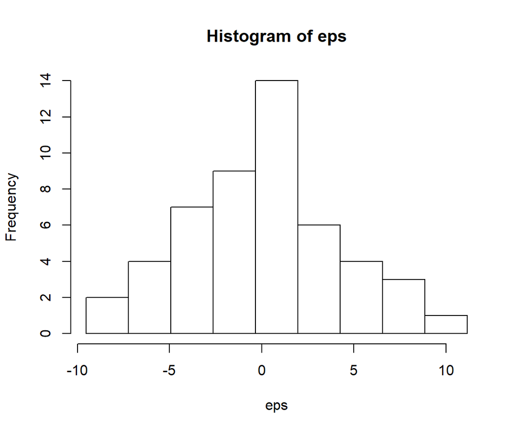

$$\begin{align}
& H_0:\varepsilon_1, ..., \varepsilon_n \sim N(0, \sigma^2) \\
& \sum\limits_{i=1}^{r}\frac{n_i-np_i(0, \sigma^2))^2}{np_i(0, \sigma^2)} \rightarrow \chi^2_{кр}
\end{align}$$

Метод минимизации хи-квадрат

$$\begin{equation}
\underset{\sigma^2}{argmin}\sum\limits_{i=1}^{r}\frac{n_i-np_i(0, \sigma^2))^2}{np_i(0, \sigma^2)}
\end{equation}$$

##### Разделим выборку на 6 зон:

| Интервал | $(-\infty; -4.6)$ | $(-4.6; -2.3)$ | $(-2.3; 0)$ | $(0; 2.3)$ | $(2.3; 4.6)$ | $(4.6; \infty)$ |
| --- | --- | --- | --- | --- | --- | --- |
| $m_i$ | 6 | 8 | 11 | 13 | 6 | 6 |

##### Получаем $\hat{\sigma}^2=14.6891651$ и $\chi^2_{набл}=0.7707681$

$$\begin{align}
l&=r - d - 1 = 4 \\
\chi^2_{кр} &=9.487729 \\
\chi^2_{набл}=0.7707681 < \chi^2_{кр} & = 9.487729 \Rightarrow \text{гипотеза $H_0$ принимается}
\end{align}$$

##### Оценим расстояние оценки до класса нормальных распределений по Колмогорову. Минимизируем статистику Колмогорова с помощью следующего скрипта:

```r
kolm.stat<-function(s){
  sres<-sort(eps)
  fdistr<-pnorm(sres,0,s)
  max(abs(c(0:(n-1))/n-fdistr),abs(c(1:n)/n-fdistr))
}
ks.dist<-nlm(kolm.stat, XM$estimate)
```

##### Получаем расстояние $D = 0.0569253$ и $\tilde{\sigma}^2 = 14.6369618$. Ниже представлены эмпирическая функция распределения ошибок и фукнция распределения $N(0, \tilde{\sigma}^2)$.

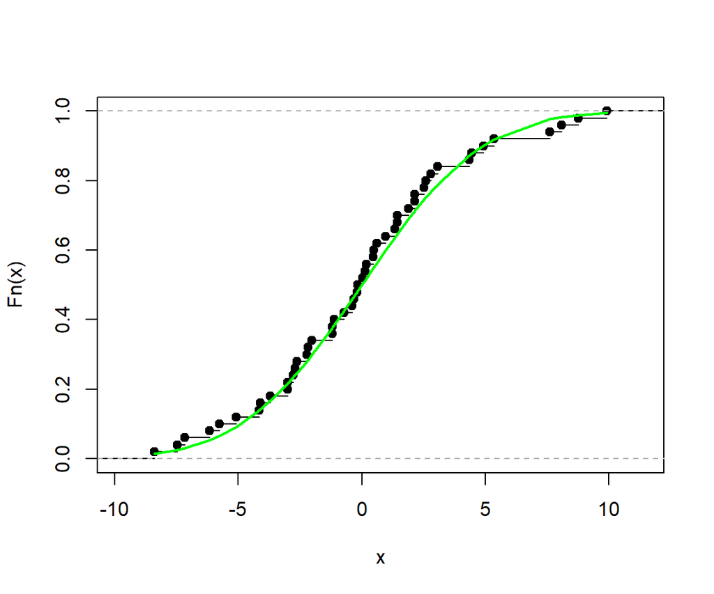

#### *Задание 7*

##### В предположении нормальности ошибок построить доверительные интервалы для параметров $\beta_1, \beta_2, \beta_3$ уровня $1-\alpha_1$. Написать уравнение доверительного эллипсоида уровня доверия $1-\alpha_1$.

$$\begin{align}
& \psi=C^T\beta; \hat{\psi}\sim N(\psi, \sigma^2C^T(XX^T)^{-1}C) \\
& x_{\alpha}: S_{n-r}(x_{\alpha})=1-\frac{\alpha}{2} \\
& P(\hat{\psi}-x_{\alpha}s\sqrt{b} \leqslant \psi \leqslant \hat{\psi}+x_{\alpha}s\sqrt{b}) \\
& x_{\alpha} = 2.0117405 \\
& \beta_1 \in (-0.3727285; 0.7821618) \text{ - ДИ с уровнем доверия }1-\alpha \\
& \beta_2 \in (-4.7808629; 2.6764392) \text{ - ДИ с уровнем доверия }1-\alpha \\
& \beta_3 \in (4.5285215; 15.9850016) \text{ - ДИ с уровнем доверия }1-\alpha
\end{align}$$

$$\begin{align}
& x_{\alpha}: F_{q, n-r}(x_{\alpha})=1-\alpha \\
& \left\{ \psi: (\hat{\psi}-\psi)^T(C^T(XX^T)^{-1}C)^{-1}(\hat{\psi}-\psi) \leqslant s^2qx_{\alpha} \right\} \\
& x_{\alpha} = 2.8023552
\end{align}$$
$$\begin{align}
& \begin{pmatrix} \beta_1-\hat{\beta_1} & \beta_2-\hat{\beta_2} & \beta_3-\hat{\beta_3} \end{pmatrix} \begin{pmatrix} 0.0047047 & -0.0293129& 0.0386766 \\ -0.0293129 & 0.1961629 & -0.2821006 \\ 0.0386766 & -0.2821006 & 0.4629731 \end{pmatrix} \begin{pmatrix} \beta_1-\hat{\beta_1} \\ \beta_2-\hat{\beta_2} \\ \beta_3-\hat{\beta_3} \end{pmatrix} \leqslant 147.2268862
\end{align}$$

$$\begin{align}
0.6452729(\beta_1^*-0.2047166)^2&+0.018461(\beta_2^*-(-1.0522118))^2+1.0685722\times 10^{-4}(\beta_3^*-10.2567615)^2 \leqslant 147.2268862 \\
\frac{(\beta_1^*-0.2047166)^2}{15.105039^2}&+\frac{(\beta_2^*-(-1.0522118))^2}{89.3029357^2}+\frac{(\beta_3^*-10.2567615)^2}{1173.7933079^2} \leqslant 1
\end{align}$$